# Business Forecasting Assignment

Deepthi JahanMohan

20/09/2025

# Creating a Employee Survey

```r
min(EmployeeSurvey$Age)
```

```
## [1] 20
```

min(EmployeeSurvey$Age)

```r
max(EmployeeSurvey$Age)
```

```
## [1] 64
```

max(EmployeeSurvey$Age)

```r
range(EmployeeSurvey$Age)
```

```
## [1] 20 64
```

range(EmployeeSurvey$Age)

```r
str(EmployeeSurvey)
```

```
## 'data.frame':    122 obs. of  11 variables:
##  $ Age                 : int  35 33 23 60 35 34 61 59 37 30 ...
##  $ Gender              : int  1 1 1 1 1 2 2 1 2 1 ...
##  $ JobSatisfaction     : int  2 2 1 1 2 2 1 2 1 1 ...
##  $ ImpCharacteristics  : int  4 3 1 1 1 1 1 5 5 5 ...
##  $ YearsinJob          : num  3 9 1.5 20 3 6 0.75 1.5 3 5 ...
##  $ Promotion           : int  1 5 1 3 3 1 5 2 4 2 ...
##  $ DecisionMaking      : int  2 2 2 2 2 2 3 1 3 2 ...
##  $ BudgetDecisionMaking: int  1 1 2 2 1 2 2 2 1 1 ...
##  $ Organization        : int  2 2 1 1 2 2 2 2 2 1 ...
##  $ JobImpact           : int  5 2 5 1 4 4 4 4 2 2 ...
##  $ Workplace           : int  2 1 2 1 2 4 1 1 3 2 ...
```

str(EmployeeSurvey)

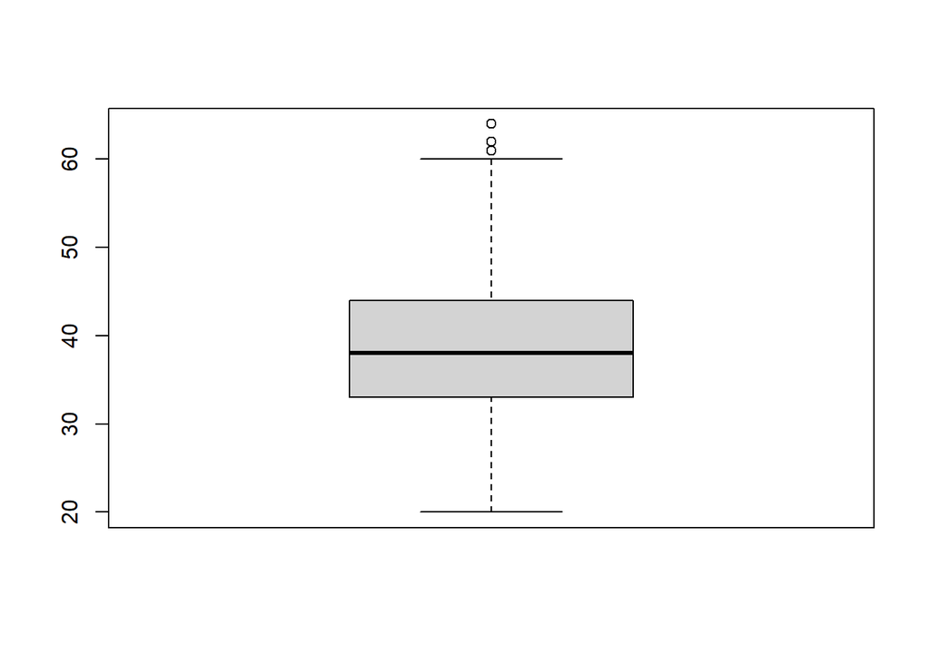

```r
# Box Plot Columns

boxplot(EmployeeSurvey$Age)
```

boxplot(EmployeeSurvey$Age)

```r
boxplot(EmployeeSurvey$Gender)
```

[output not shown]

boxplot(EmployeeSurvey$Gender)

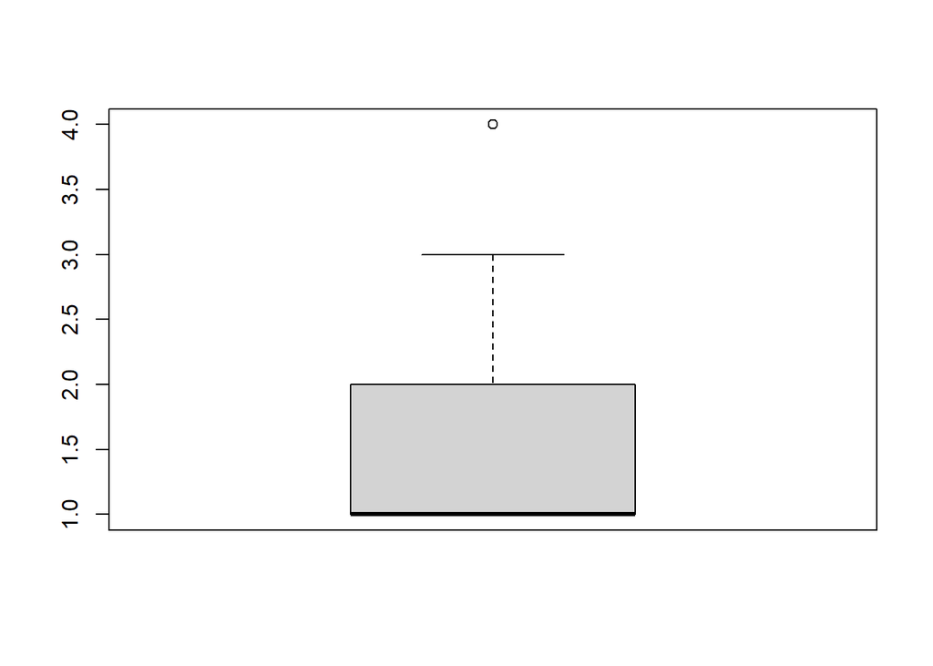

```r
boxplot(EmployeeSurvey$JobSatisfaction)
```

boxplot(EmployeeSurvey$JobSatisfaction)

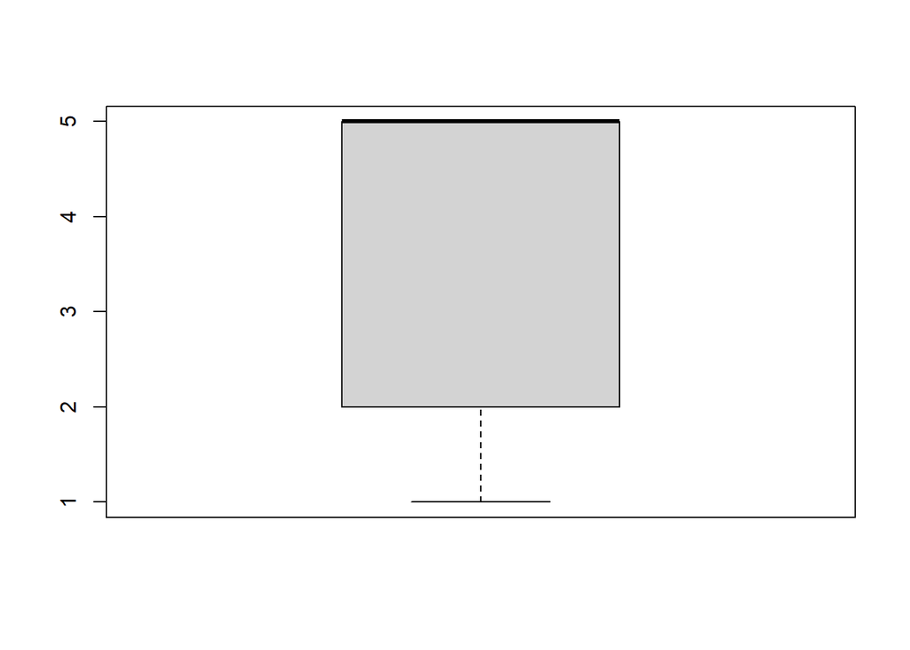

```r
boxplot(EmployeeSurvey$ImpCharacteristics)
```

boxplot(EmployeeSurvey$ImpCharacteristics)

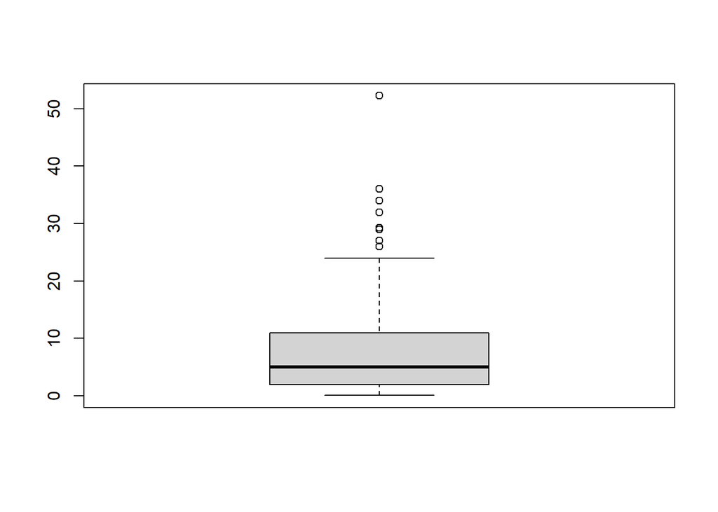

```r
boxplot(EmployeeSurvey$YearsinJob)
```

boxplot(EmployeeSurvey$YearsinJob)

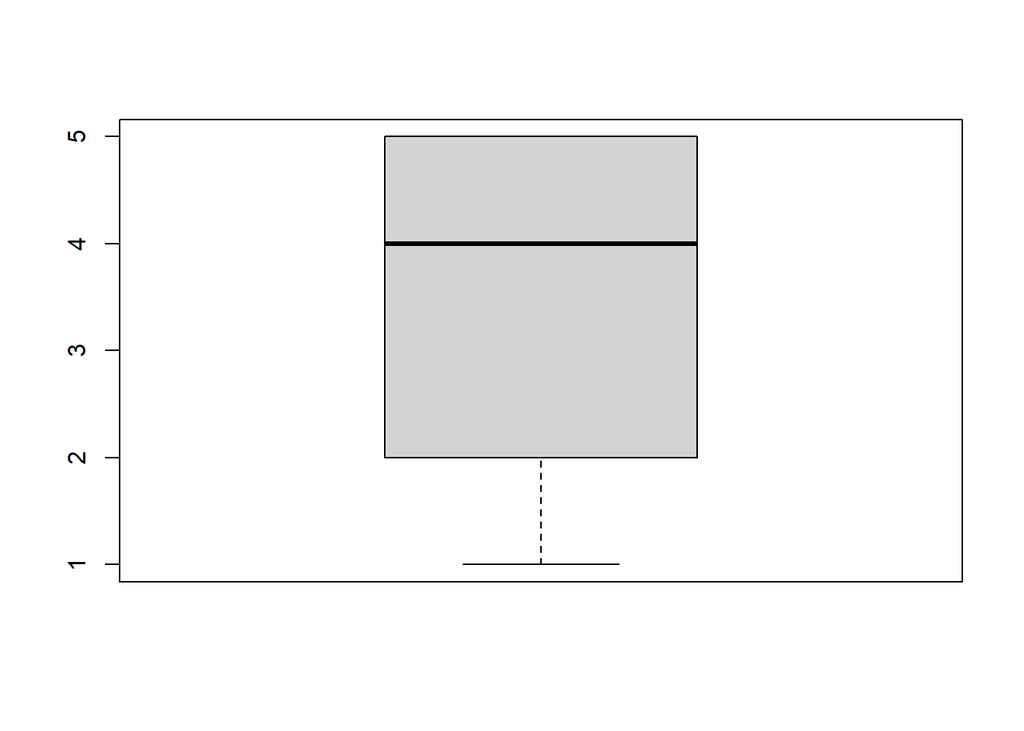

```r
boxplot(EmployeeSurvey$Promotion)
```

boxplot(EmployeeSurvey$Promotion)

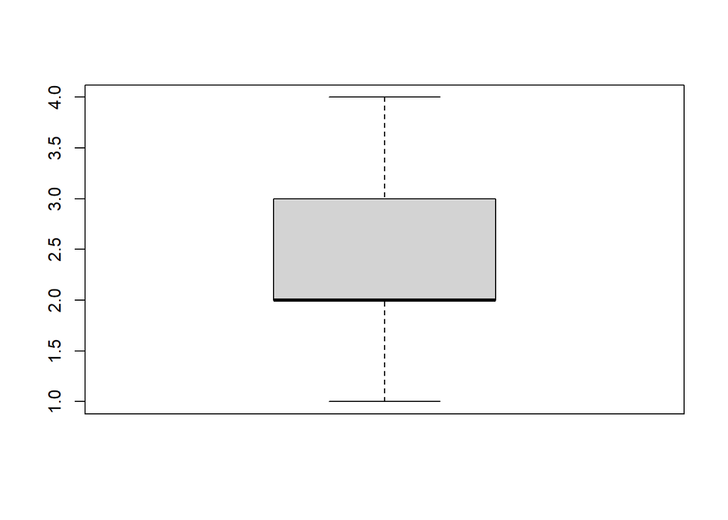

```r
boxplot(EmployeeSurvey$DecisionMaking)
```

boxplot(EmployeeSurvey$DecisionMaking)

```r
boxplot(EmployeeSurvey$BudgetDecisionMaking)
```

[output not shown]

boxplot(EmployeeSurvey$BudgetDecisionMaking)

```r
boxplot(EmployeeSurvey$BudgetDecisionMaking)
```

[output not shown]

boxplot(EmployeeSurvey$BudgetDecisionMaking)

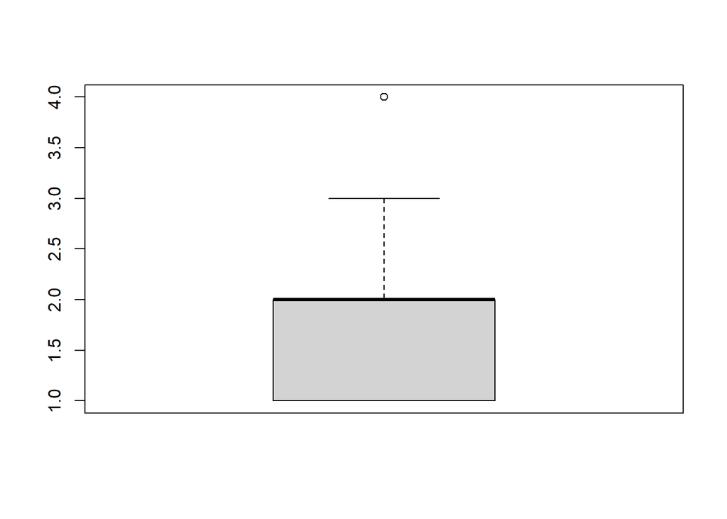

```r
boxplot(EmployeeSurvey$Organization)
```

boxplot(EmployeeSurvey$Organization)

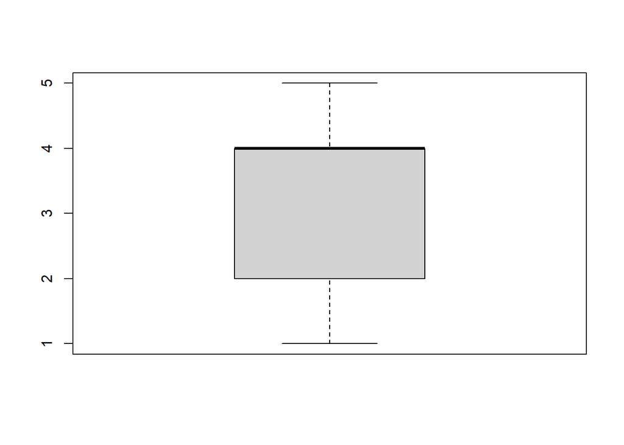

```r
boxplot(EmployeeSurvey$JobImpact)
```

boxplot(EmployeeSurvey$JobImpact)

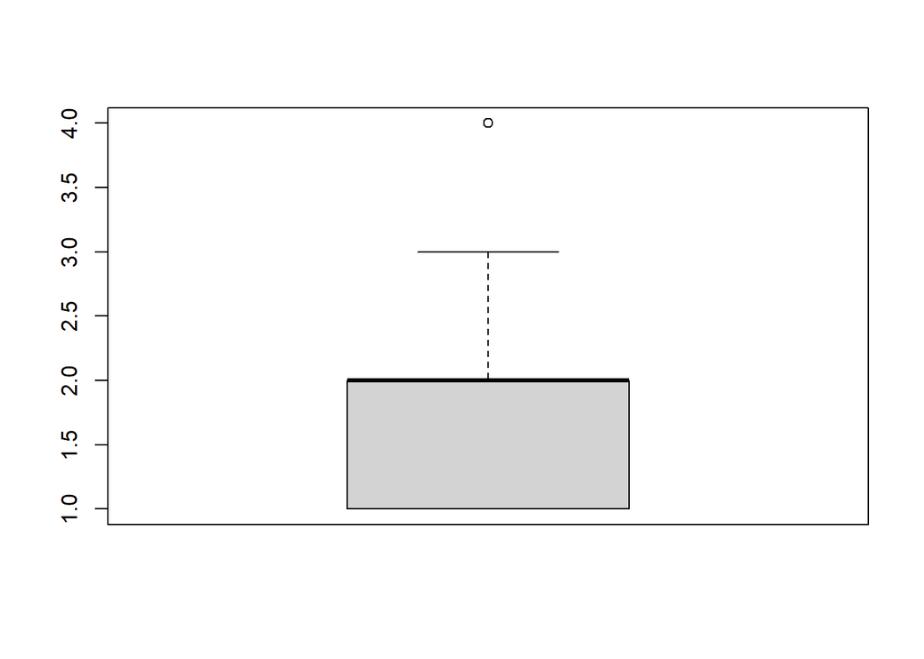

```r
boxplot(EmployeeSurvey$Workplace)
```

boxplot(EmployeeSurvey$Workplace)

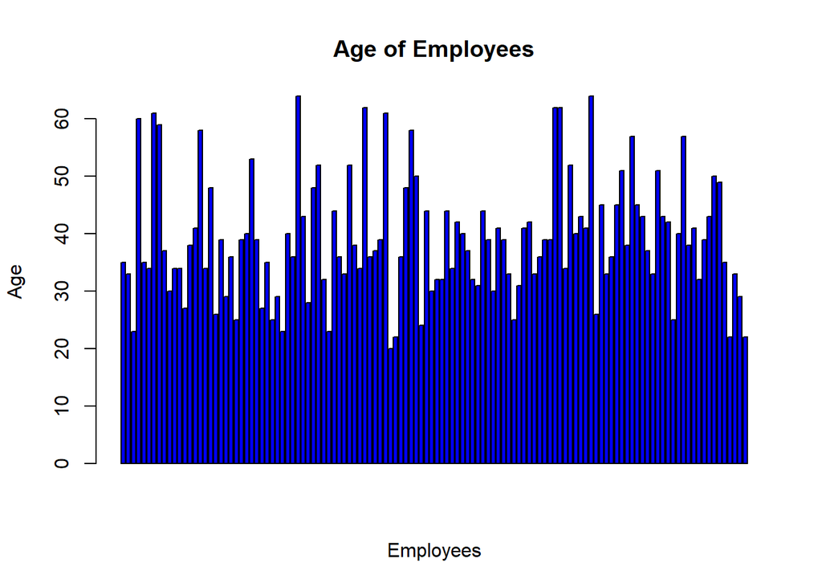

```r
# Graphing

barplot(EmployeeSurvey$Age, main = "Age of Employees", xlab = "Employees", ylab = "Age", col = "Blue")
```

barplot(EmployeeSurvey$Age, main = “Age of Employees”, xlab = “Employees”, ylab = “Age”, col = “Blue”)

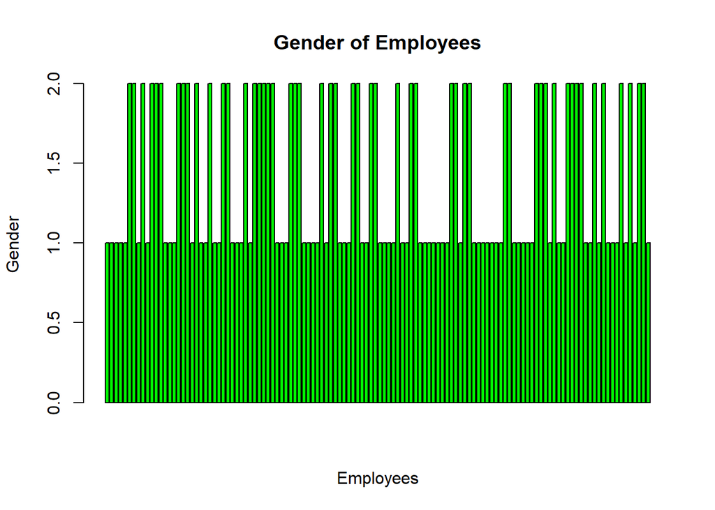

```r
barplot(EmployeeSurvey$Gender, main = "Gender of Employees", xlab = "Employees", ylab = "Gender", col = "Green")
```

barplot(EmployeeSurvey$Gender, main = “Gender of Employees”, xlab = “Employees”, ylab = “Gender”, col = “Green”)

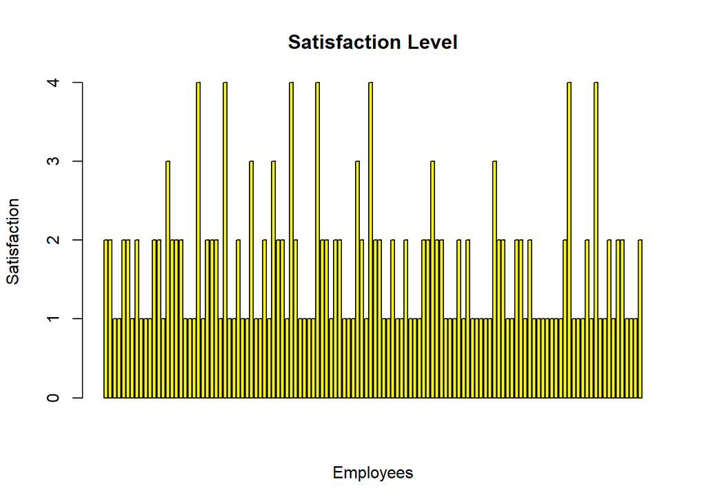

```r
barplot(EmployeeSurvey$JobSatisfaction, main = "Satisfaction Level", xlab = "Employees", ylab = "Satisfaction", col = "Yellow")
```

barplot(EmployeeSurvey$JobSatisfaction, main = “Satisfaction Level”, xlab = “Employees”, ylab = “Satisfaction”, col = “Yellow”)

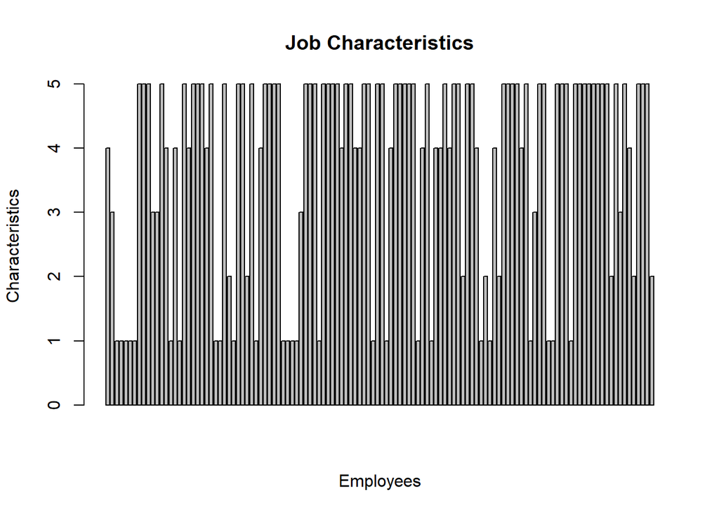

```r
barplot(EmployeeSurvey$ImpCharacteristics, main = "Job Characteristics", xlab = "Employees", ylab = "Characteristics", col = "Grey")
```

barplot(EmployeeSurvey$ImpCharacteristics, main = “Job Characteristics”, xlab = “Employees”, ylab = “Characteristics”, col = “Grey”)

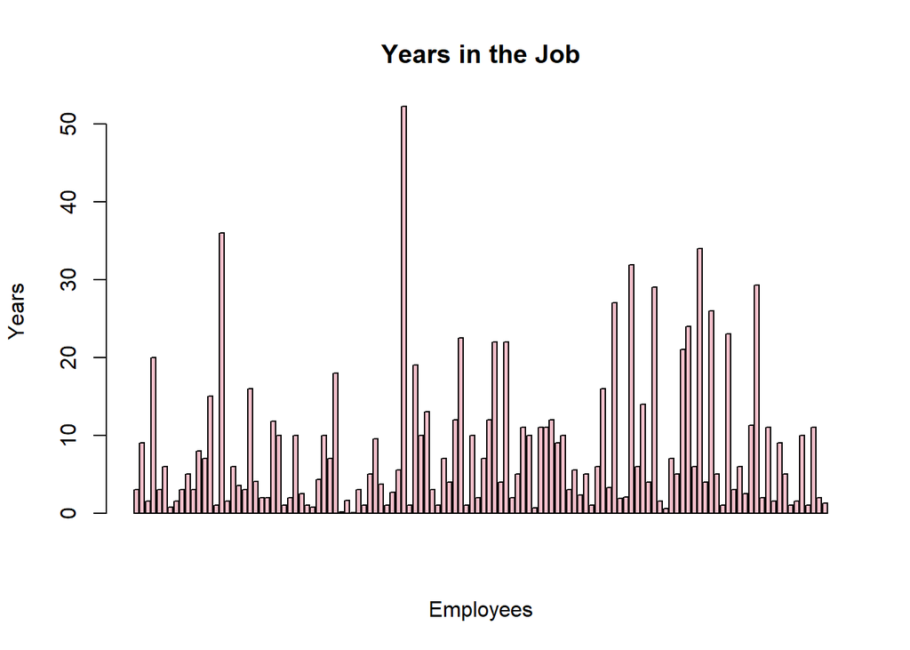

```r
barplot(EmployeeSurvey$YearsinJob, main = "Years in the Job", xlab = "Employees", ylab = "Years", col = "Pink")
```

barplot(EmployeeSurvey$YearsinJob, main = “Years in the Job”, xlab = “Employees”, ylab = “Years”, col = “Pink”)

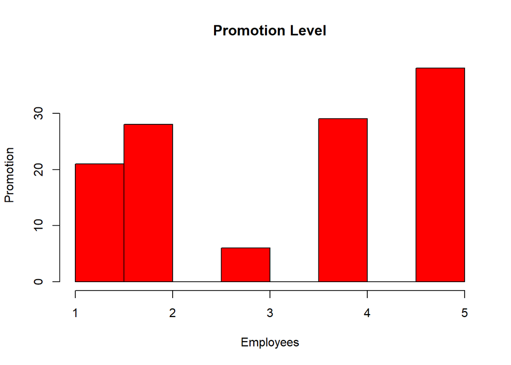

```r
hist(EmployeeSurvey$Promotion, main = "Promotion Level", xlab = "Employees", ylab = "Promotion", col = "Red")
```

hist(EmployeeSurvey$Promotion, main = “Promotion Level”, xlab = “Employees”, ylab = “Promotion”, col = “Red”)

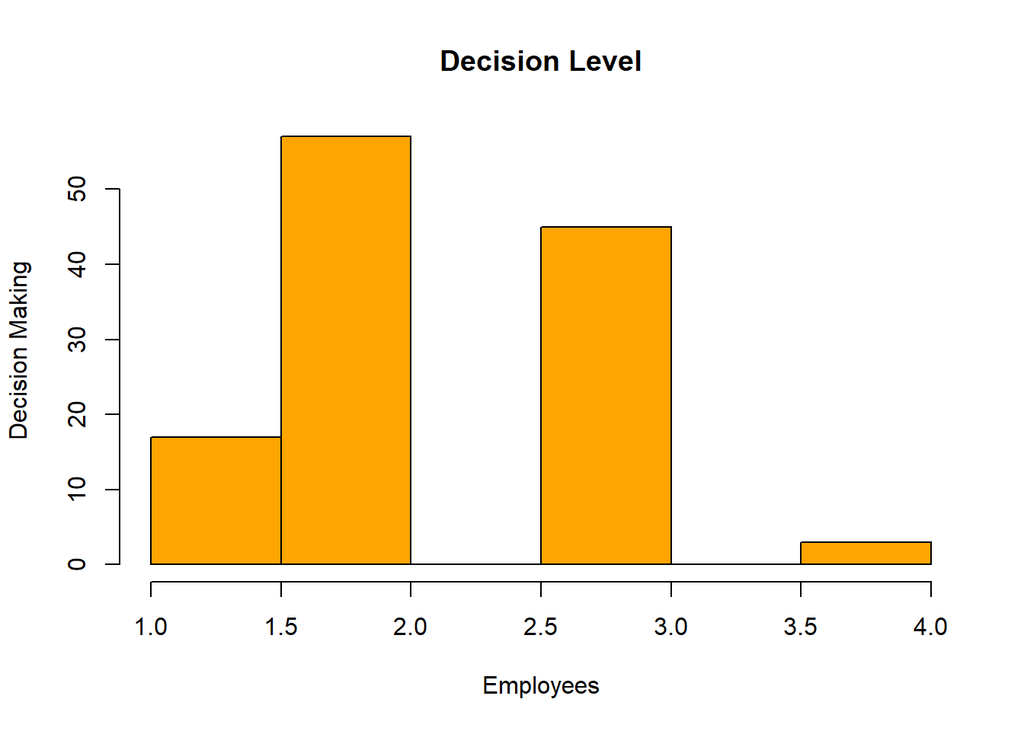

```r
hist(EmployeeSurvey$DecisionMaking, main = "Decision Level", xlab = "Employees", ylab = "Decision Making", col = "Orange")
```

hist(EmployeeSurvey$DecisionMaking, main = “Decision Level”, xlab = “Employees”, ylab = “Decision Making”, col = “Orange”)

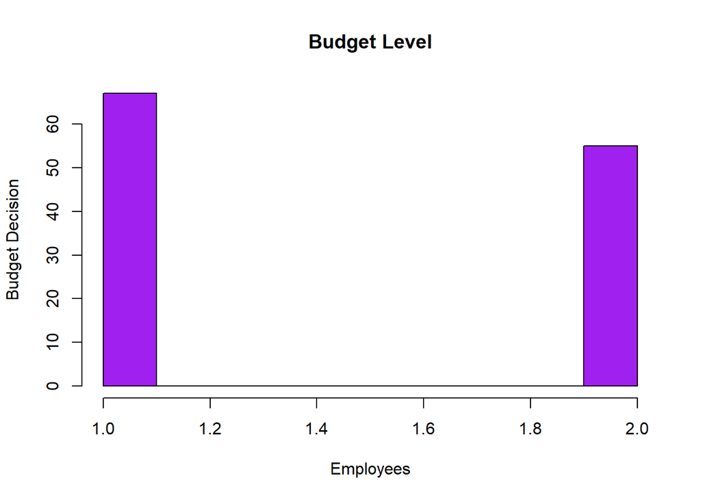

```r
hist(EmployeeSurvey$BudgetDecisionMaking, main = "Budget Level", xlab = "Employees", ylab = "Budget Decision", col = "Purple")
```

hist(EmployeeSurvey$BudgetDecisionMaking, main = “Budget Level”, xlab = “Employees”, ylab = “Budget Decision”, col = “Purple”)

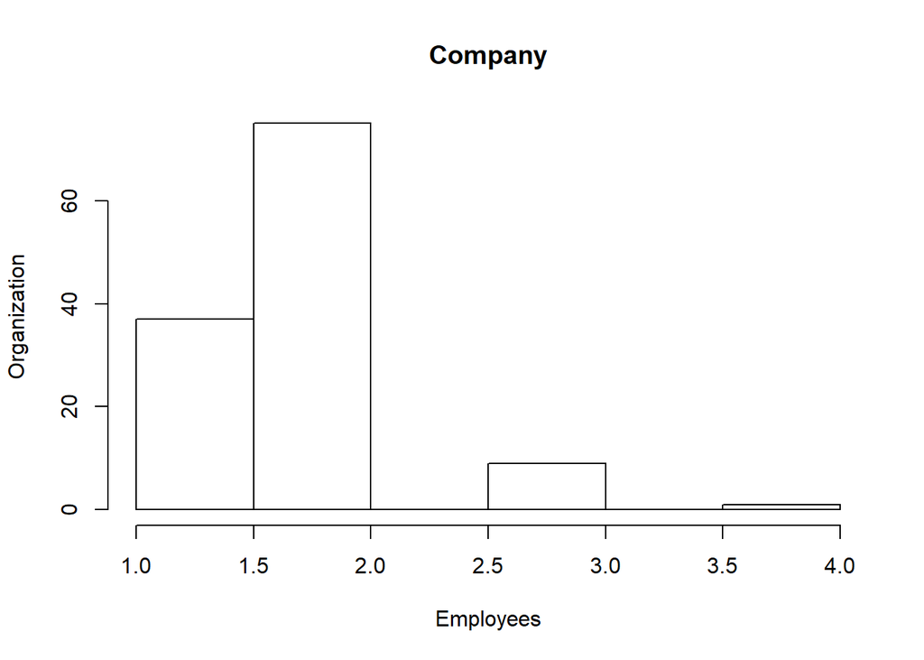

```r
hist(EmployeeSurvey$Organization, main = "Company", xlab = "Employees", ylab = "Organization", col = "White")
```

hist(EmployeeSurvey$Organization, main = “Company”, xlab = “Employees”, ylab = “Organization”, col = “White”)

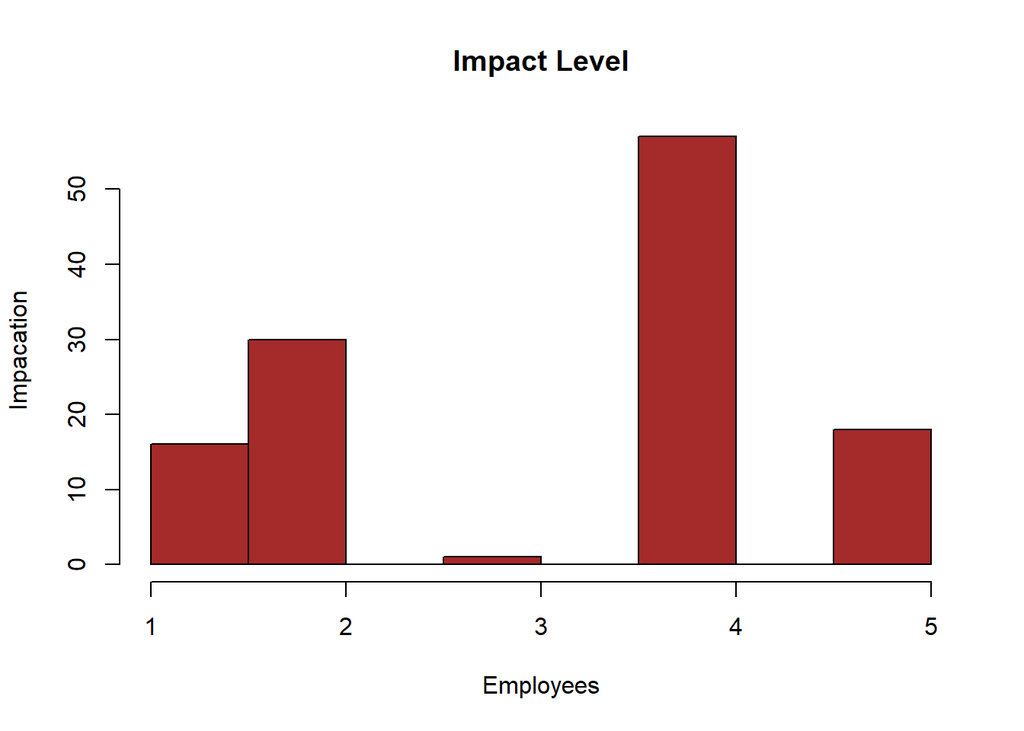

```r
hist(EmployeeSurvey$JobImpact, main = "Impact Level", xlab = "Employees", ylab = "Impacation", col = "Brown")
```

hist(EmployeeSurvey$JobImpact, main = “Impact Level”, xlab = “Employees”, ylab = “Impacation”, col = “Brown”)

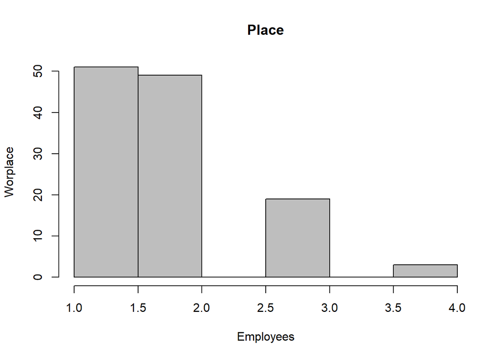

```r
hist(EmployeeSurvey$Workplace, main = "Place", xlab = "Employees", ylab = "Worplace", col = "Grey")
```

hist(EmployeeSurvey$Workplace, main = “Place”, xlab = “Employees”, ylab = “Worplace”, col = “Grey”)

```r
# Columns

EmployeeSurvey$Age <- as.factor(EmployeeSurvey$Age)
class(EmployeeSurvey$Age)
```

```
## [1] "factor"
```

class(EmployeeSurvey$Age)

```r
EmployeeSurvey$Gender <- as.factor(EmployeeSurvey$Gender)
class(EmployeeSurvey$Gender)
```

```
## [1] "factor"
```

class(EmployeeSurvey$Gender)

```r
EmployeeSurvey$YearsinJob <- as.factor(EmployeeSurvey$YearsinJob)
class(EmployeeSurvey$YearsinJob)
```

```
## [1] "factor"
```

class(EmployeeSurvey$YearsinJob)

```r
str(EmployeeSurvey)
```

```
## 'data.frame':    122 obs. of  11 variables:
##  $ Age                 : Factor w/ 38 levels "20","22","23",..: 15 13 3 35 15 14 36 34 17 10 ...
##  $ Gender              : Factor w/ 2 levels "1","2": 1 1 1 1 1 2 2 1 2 1 ...
##  $ JobSatisfaction     : int  2 2 1 1 2 2 1 2 1 1 ...
##  $ ImpCharacteristics  : int  4 3 1 1 1 1 1 5 5 5 ...
##  $ YearsinJob          : Factor w/ 54 levels "0.08","0.16",..: 16 28 8 41 16 25 5 8 16 23 ...
##  $ Promotion           : int  1 5 1 3 3 1 5 2 4 2 ...
##  $ DecisionMaking      : int  2 2 2 2 2 2 3 1 3 2 ...
##  $ BudgetDecisionMaking: int  1 1 2 2 1 2 2 2 1 1 ...
##  $ Organization        : int  2 2 1 1 2 2 2 2 2 1 ...
##  $ JobImpact           : int  5 2 5 1 4 4 4 4 2 2 ...
##  $ Workplace           : int  2 1 2 1 2 4 1 1 3 2 ...
```

str(EmployeeSurvey)

```r
EmployeeSurvey$Age <- as.numeric(EmployeeSurvey$Age)
class(EmployeeSurvey$Age)
```

```
## [1] "numeric"
```

class(EmployeeSurvey$Age)

```r
EmployeeSurvey$Organization <- as.factor(EmployeeSurvey$Organization)
class(EmployeeSurvey$Organization)
```

```
## [1] "factor"
```

class(EmployeeSurvey$Organization)

```r
str(EmployeeSurvey)
```

```
## 'data.frame':    122 obs. of  11 variables:
##  $ Age                 : num  15 13 3 35 15 14 36 34 17 10 ...
##  $ Gender              : Factor w/ 2 levels "1","2": 1 1 1 1 1 2 2 1 2 1 ...
##  $ JobSatisfaction     : int  2 2 1 1 2 2 1 2 1 1 ...
##  $ ImpCharacteristics  : int  4 3 1 1 1 1 1 5 5 5 ...
##  $ YearsinJob          : Factor w/ 54 levels "0.08","0.16",..: 16 28 8 41 16 25 5 8 16 23 ...
##  $ Promotion           : int  1 5 1 3 3 1 5 2 4 2 ...
##  $ DecisionMaking      : int  2 2 2 2 2 2 3 1 3 2 ...
##  $ BudgetDecisionMaking: int  1 1 2 2 1 2 2 2 1 1 ...
##  $ Organization        : Factor w/ 4 levels "1","2","3","4": 2 2 1 1 2 2 2 2 2 1 ...
##  $ JobImpact           : int  5 2 5 1 4 4 4 4 2 2 ...
##  $ Workplace           : int  2 1 2 1 2 4 1 1 3 2 ...
```

str(EmployeeSurvey)

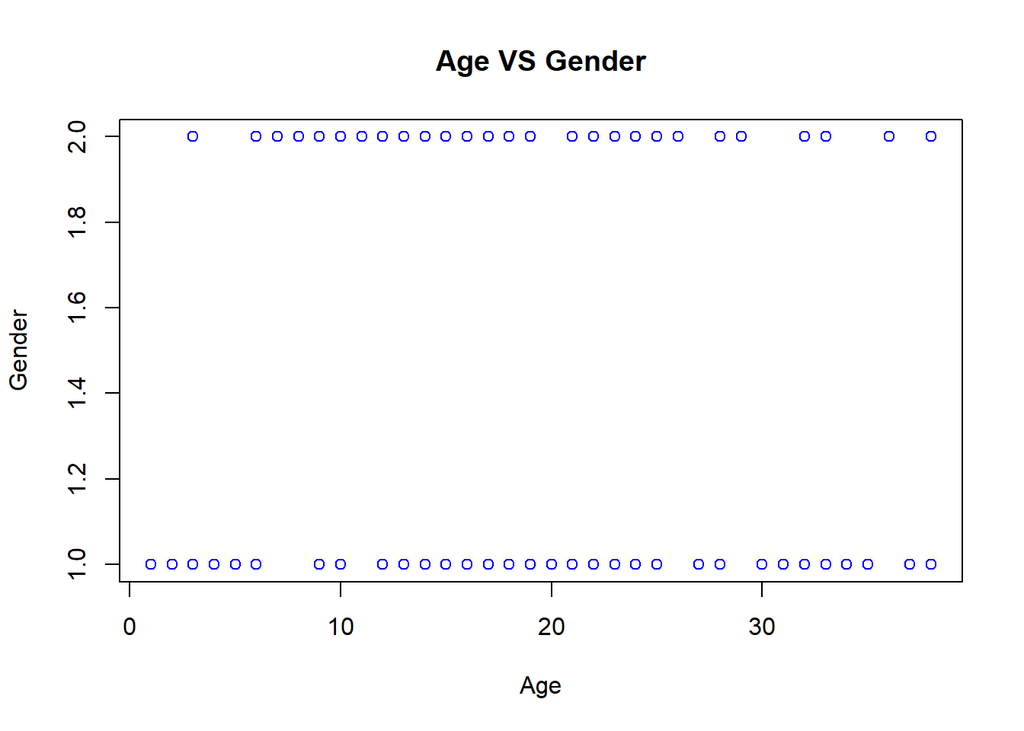

```r
# Scatter Plots

plot(EmployeeSurvey$Age, EmployeeSurvey$Gender, main = "Age VS Gender", xlab = "Age", ylab = "Gender", col = "Blue")
```

plot(EmployeeSurvey$Age, EmployeeSurvey$Gender, main = “Age VS Gender”, xlab = “Age”, ylab = “Gender”, col = “Blue”)

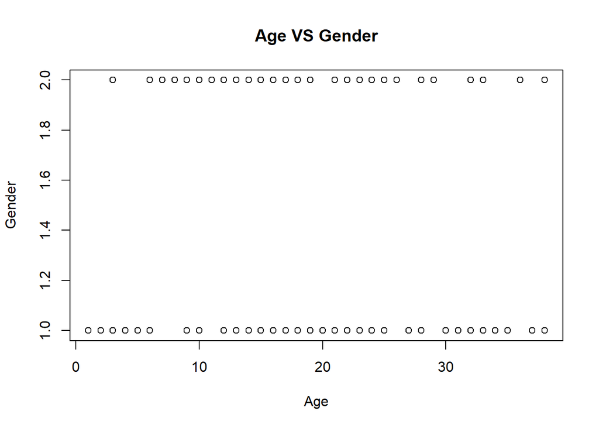

```r
plot(x=EmployeeSurvey$Age,y=EmployeeSurvey$Gender, main = "Age VS Gender", xlab = "Age", ylab = "Gender")
```

plot(x=EmployeeSurvey$Age,y=EmployeeSurvey$Gender, main = “Age VS Gender”, xlab = “Age”, ylab = “Gender”)

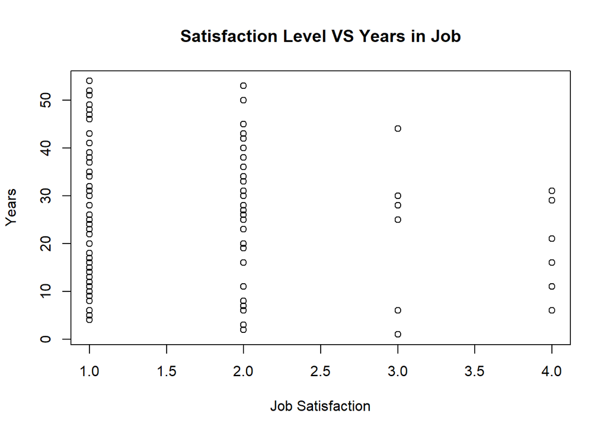

```r
plot(x=EmployeeSurvey$JobSatisfaction, y=EmployeeSurvey$YearsinJob, main = "Satisfaction Level VS Years in Job", xlab = "Job Satisfaction", ylab = "Years")
```

plot(x=EmployeeSurvey$JobSatisfaction, y=EmployeeSurvey$YearsinJob, main = “Satisfaction Level VS Years in Job”, xlab = “Job Satisfaction”, ylab = “Years”)

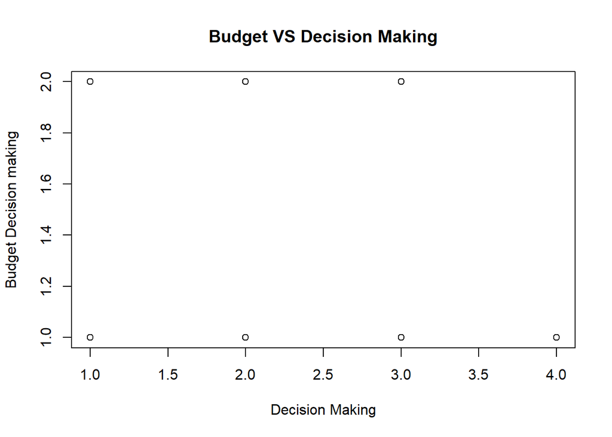

```r
plot(x=EmployeeSurvey$DecisionMaking, y=EmployeeSurvey$BudgetDecisionMaking, main = "Budget VS Decision Making", xlab = "Decision Making", ylab = "Budget Decision making")
```

plot(x=EmployeeSurvey$DecisionMaking, y=EmployeeSurvey$BudgetDecisionMaking, main = “Budget VS Decision Making”, xlab = “Decision Making”, ylab = “Budget Decision making”)